# Disaster Relief Project: Part II Model Build & Test Data

Ashlie Ossege ajo5fs

May 10, 2021

# 1 Introduction

It was 2012. I was floating on a raft in the crystal clear Haitian waters with the sun warming my face, and coconut and fruit on my tongue. Peering though my Ralph Lauren sunglasses, I catch sight of a deflated plastic juice-bag-shaped object floating by. I could make out the word ‘water’. In that moment I was hit with the bleak reminder of the devastation that occurred just on the other side of the beautiful mountain tops in 2010. The earthquake that left families and children hungry, longing for food and shelter and suffering the loss of loved ones. These water sachets or ‘saches dlo’ are commonly distributed throughout Haiti in times of disaster and times of peace, providing potable water to those who call Haiti their home.

How was aid distributed to the 300,000 people that were injured in the earthquake and 5 million* displaced? Analysis of the disaster relief data reveals the power of data mining in helping provide actionable insights for social aid for incomprehensible conditions.

*Worldvision.org

# 2 Training Data / EDA

```r
# Load Required Packages
library(tidyverse)
library(broom)
library(yardstick)  ##https://yardstick.tidymodels.org/reference/roc_auc.html
library(kableExtra)
library(ISLR)
library(pheatmap)
library(dplyr)
library(ggplot2)
library(ROCR)
library(MASS)
library(class)
library(glmnet)
library(knitr)


setwd("C:/Users/ajoss/Documents/Data Mining SYS6018 Spring2021")
haiti <- read.csv(file = 'HaitiPixels.csv')
head(haiti)
```

```
##        Class Red Green Blue
## 1 Vegetation  64    67   50
## 2 Vegetation  64    67   50
## 3 Vegetation  64    66   49
## 4 Vegetation  75    82   53
## 5 Vegetation  74    82   54
## 6 Vegetation  72    76   52
```

```r
summary(haiti)
```

```
##     Class                Red          Green            Blue
##  Length:63241       Min.   : 48   Min.   : 48.0   Min.   : 44.0
##  Class :character   1st Qu.: 80   1st Qu.: 78.0   1st Qu.: 63.0
##  Mode  :character   Median :163   Median :148.0   Median :123.0
##                     Mean   :163   Mean   :153.7   Mean   :125.1
##                     3rd Qu.:255   3rd Qu.:226.0   3rd Qu.:181.0
##                     Max.   :255   Max.   :255.0   Max.   :255.0
```

```r
attach(haiti)
mytable <-table(Class)
mytable
```

```
## Class
##        Blue Tarp          Rooftop             Soil Various Non-Tarp
##             2022             9903            20566             4744
##       Vegetation
##            26006
```

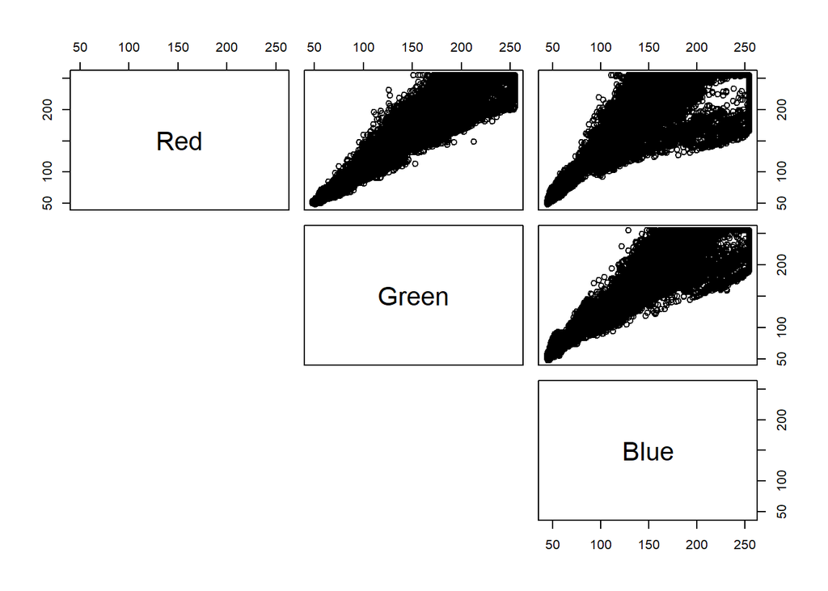

```r
pairs(haiti[sapply(haiti,is.numeric)], lower.panel = NULL)
```

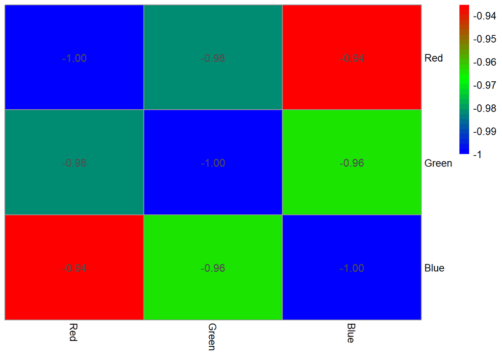

```r
library(pheatmap)
haiti.corr<--cor(haiti[sapply(haiti,is.numeric)])
pheatmap(haiti.corr, display_numbers = T, color = colorRampPalette(c("blue", "green", "red"))(30), cluster_rows = F, cluster_cols = F, fontsize_number = 11)
```

```r
library(dplyr)
haiti %>%
  group_by(Class) %>%
  summarize(COR=cor(Blue,Red))
```

```
## # A tibble: 5 x 2
##   Class              COR
## * <chr>            <dbl>
## 1 Blue Tarp        0.859
## 2 Rooftop          0.946
## 3 Soil             0.660
## 4 Various Non-Tarp 0.898
## 5 Vegetation       0.946
```

```r
haiti %>%
  group_by(Class) %>%
  summarize(COR=cor(Blue,Green))
```

```
## # A tibble: 5 x 2
##   Class              COR
## * <chr>            <dbl>
## 1 Blue Tarp        0.926
## 2 Rooftop          0.985
## 3 Soil             0.840
## 4 Various Non-Tarp 0.959
## 5 Vegetation       0.905
```

```r
haiti %>%
  group_by(Class) %>%
  summarize(COR=cor(Red,Green))
```

```
## # A tibble: 5 x 2
##   Class              COR
## * <chr>            <dbl>
## 1 Blue Tarp        0.969
## 2 Rooftop          0.977
## 3 Soil             0.802
## 4 Various Non-Tarp 0.963
## 5 Vegetation       0.938
```

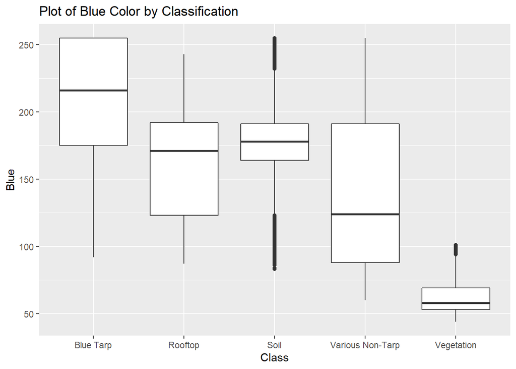

```r
library(ggplot2)
ggplot(haiti, aes(x=Class, y=Blue)) +
  geom_boxplot() +  ggtitle("Plot of Blue Color by Classification")
```

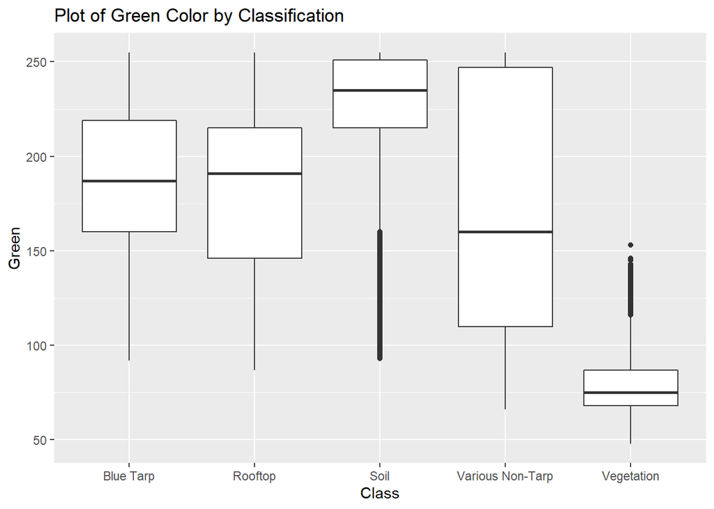

```r
ggplot(haiti, aes(x=Class, y=Green)) +
  geom_boxplot() + ggtitle("Plot of Green Color by Classification")
```

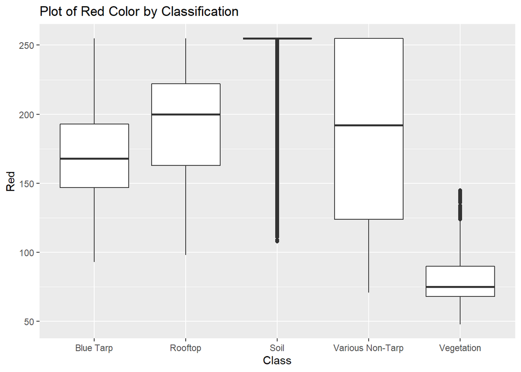

```r
ggplot(haiti, aes(x=Class, y=Red)) +
  geom_boxplot() + ggtitle("Plot of Red Color by Classification")
```

Summary from EDA:

1. 2022 observations are BlueTarp or 3.2% of the observations.
2. The distribution of the “Blue” codes for “Blue Tarps” have the highest median of ~215 compared to the other classifications.
3. Vegetation has the lowest blue code values of code 100 or less.
4. RGB Variables are correlated
5. Red and Green have a higher correlation under BlueTarp classification (0.9690130), than Blue & Green (0.9257670 ), or Blue & Red (0.8594749)

# 3 Model Training

## 3.1 Test & Train Set-up

```r
haiti$Class.Dummy <- 0
haiti$Class.Dummy <- ifelse(haiti$Class=="Blue Tarp",1,0)
attach(haiti)
set.seed(914)
test20 = .20*nrow(haiti)
haiti.test = sample(nrow(haiti),test20 )  #vector of obs numbers
haiti.train = -haiti.test                 #removal of obs numbers for matrix
```

## 3.2 Logistic Regression

```r
#k-fold 10

M = 10
n_test = as.integer(nrow(haiti)/M)

set.seed(552)

logistic.error = numeric(M)
for(m in 1:M) {
  # Create test and train split
  test = sample(nrow(haiti), n_test)
  train = -test
  # Fitting the model
  glm.predict = glm(Class.Dummy ~ Red + Green + Blue,
                family=binomial,
                data=haiti[train,])
  # Predictions
  p_hat = predict(glm.predict, haiti[test,], type = "response")
  cutoff.mn = mean(p_hat)
  cutoff.md = median(p_hat)
  cutoff = cutoff.mn + ((cutoff.mn - cutoff.md)/2)
  lm.cutoff = .034
  g_hat = ifelse(p_hat > cutoff, 1, 0)
  # Test Error
  logistic.error[m] = mean(haiti$Class.Dummy[test] != g_hat)
}
logistic.error
```

```
##  [1] 0.01265022 0.01280835 0.01454775 0.01502214 0.01185958 0.01280835
##  [7] 0.01201771 0.01438963 0.01280835 0.01454775
```

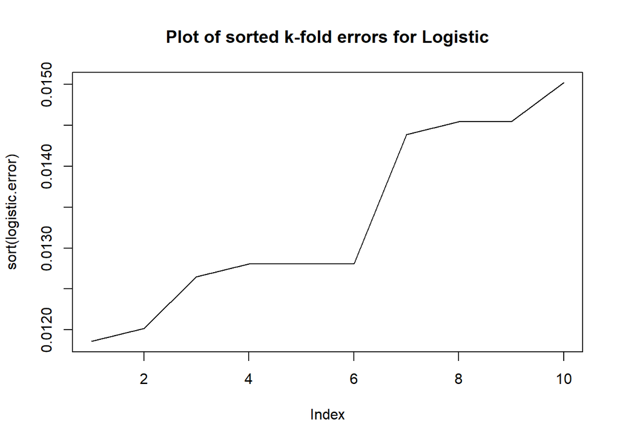

```r
plot(sort(logistic.error), type = "l", main="Plot of sorted k-fold errors for Logistic")
```

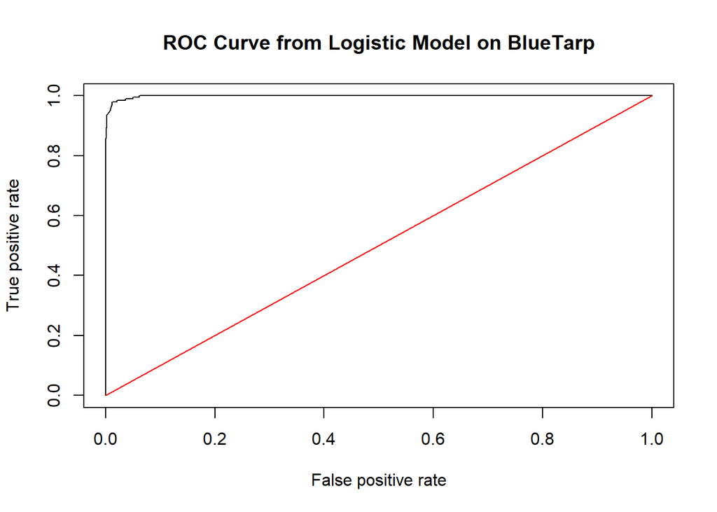

```r
#AUROC
library(ROCR)

#Apply to test data

p_hat = predict(glm.predict, haiti[test,], type = "response")

#Classification table for ROC
c_rate<-prediction(p_hat, haiti$Class.Dummy[test])
roc_data<-performance(c_rate, measure="tpr" , x.measure="fpr")
plot(roc_data, main="ROC Curve from Logistic Model on BlueTarp")
lines( x = c(0,1), y = c(0,1),col="red")
```

```r
#Find AUC
auc<-performance(c_rate, measure = "auc")
lm.auc <-auc@y.values[[1]]

##confusion matrix
lm.table <- table(haiti$Class.Dummy[test], p_hat>lm.cutoff)
lm.table
```

```
##
##     FALSE TRUE
##   0  6022  112
##   1     4  186
```

```r
lm.applied <- cbind(haiti$Class.Dummy[test],p_hat>lm.cutoff)
```

### 3.2.1 Logistic Tuning

Since we are performing a standard logistic regression with no penalties or other hyperparameters, there aren’t specific tuning parameters in this model.

### 3.2.2 Logistic Threshold Justification

I originally looked at the mean as the cut-off for the threshold so that it would vary between test samples. After reviewing the classifications tables I determined I would rather have 100% true positives at the cost of getting some false positives because it’s better to think there is a tarp versus there is a tarp, but we didn’t predict one to be there. I iteratively increased the cutoff value from the mean and landed on .034 which reduces the Type I error, with the least amount of observations in the test set classified as not having a tarp, when in fact they do (n=4).

## 3.3 LDA

```r
#k-fold 10

lda.error = numeric(M)
for(m in 1:M) {
  # Create test and train split
  haiti.test = sample(nrow(haiti), n_test)
  haiti.train = -test

  # Fitting the model
  lda.fit=lda(Class.Dummy~Red+Green+Blue, data=haiti,subset=haiti.train) #An index vector cases to be used in  training sample
  lda.fit
 # plot(lda.fit)

  # Predictions
  lda.pred = predict(lda.fit, haiti[haiti.test,])
  lda.class = lda.pred$class #predictions of BlueTarp on test data
  lda.cutoff = .015
  lda.class.adj <- ifelse(lda.pred$posterior[, 2] > lda.cutoff, "TRUE", "FALSE")  #tried between .01 & .035
  lda.class.adj <-lda.class.adj == "TRUE"
  # Test Error

  lda.table = table(haiti$Class.Dummy[haiti.test],lda.class.adj)


  lda.error[m] = mean(haiti$Class.Dummy[haiti.test] != lda.class.adj)
}
lda.error
```

```
##  [1] 0.01897533 0.02403542 0.02134725 0.02166350 0.02577483 0.01897533
##  [7] 0.02055661 0.02387729 0.02356104 0.01929159
```

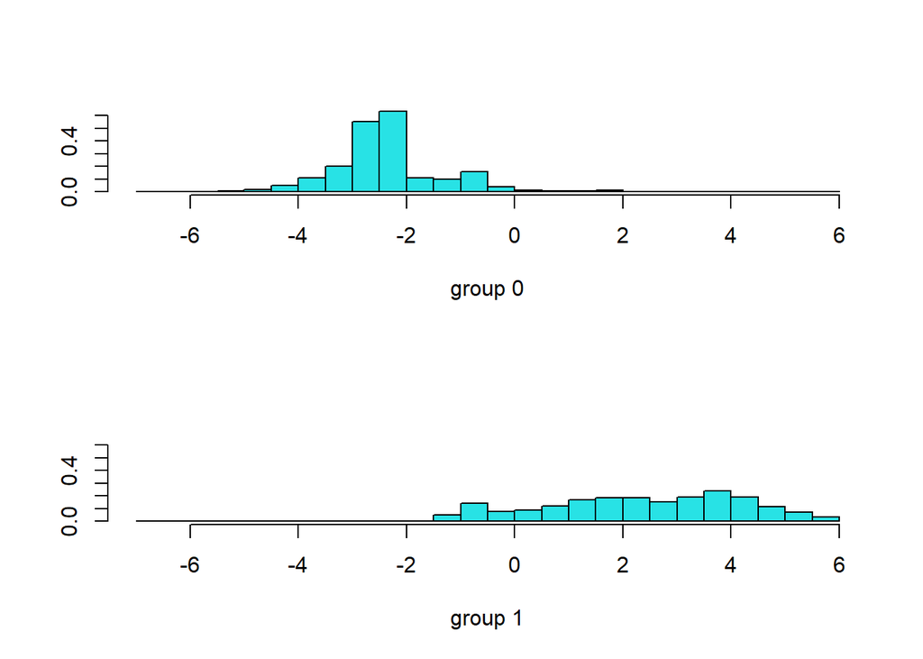

```r
plot(lda.fit)
```

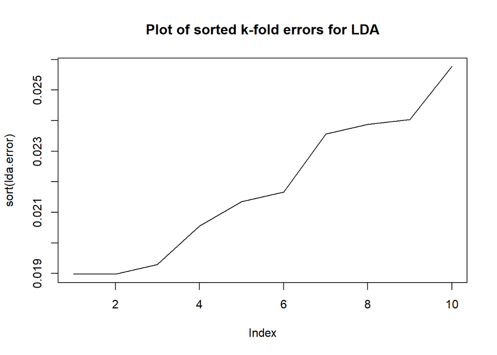

```r
plot(sort(lda.error), type = "l", main="Plot of sorted k-fold errors for LDA")
```

```r
lda.table
```

```
##    lda.class.adj
##     FALSE TRUE
##   0  6017   97
##   1    25  185
```

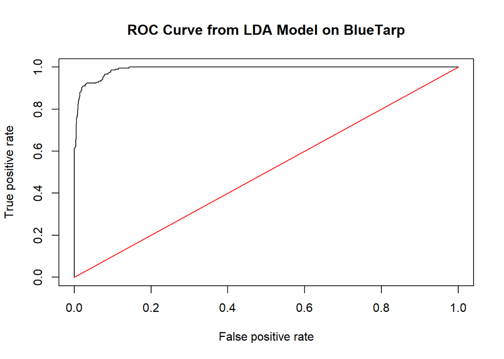

```r
#AUROC
library(ROCR)

#Apply to test data

lda.pred = predict(lda.fit, haiti[haiti.test,])

#Convert posterirors to dataframe
lda.pred.post <-as.data.frame(lda.pred$posterior)

#Classification table for ROC
lda.btarp<-prediction(lda.pred.post[,2], as.data.frame(haiti$Class.Dummy[haiti.test]))
roc_data<-performance(lda.btarp, measure="tpr" , x.measure="fpr")
plot(roc_data, main="ROC Curve from LDA Model on BlueTarp")
lines( x = c(0,1), y = c(0,1),col="red")
```

```r
#Find AUC (higher is better)
auc<-performance(lda.btarp, measure = "auc")
lda.auc = auc@y.values[[1]]

##confusion matrix
lda.table = table(haiti$Class.Dummy[haiti.test],lda.class.adj)
```

### 3.3.1 LDA Tuning

There aren’t specific tuning parameters in this model.

### 3.3.2 LDA Threshold Justification

As with Logistic, I originally looked at the mean as the cut-off for the threshold so that it would vary between test samples. After reviewing the classifications tables and knowing I would rather have 100% true positives at the cost of getting some false positives because it’s better to think there is a tarp versus there is a tarp, but we didn’t predict one to be there. Through iterations, I decreased the cutoff value by .002 increments from the mean and landed on .015 which reduces the Type I error, with the least amount of observations in the test set classified as not having a tarp, when in fact they do.

## 3.4 QDA

```r
#k-fold 10



qda.error = numeric(M)
for(m in 1:M) {
  # Create test and train split
  haiti.test = sample(nrow(haiti), n_test)
  haiti.train = -test

  # Fitting the model
  qda.fit<- qda(Class.Dummy ~ Red + Green + Blue, data=haiti,subset=haiti.train)
  qda.fit


  # Predictions
  qda.class = predict(qda.fit,haiti[haiti.test,] )$class #predictions of BlueTarp on test data
  qda.post = predict(qda.fit,haiti[haiti.test,] )$posterior


  #Threshold Adjustments
  qda.cutoff = .5
  qda.class.adj <- ifelse(qda.post[, 2] > qda.cutoff, "TRUE", "FALSE")
  qda.class.adj <-qda.class.adj == "TRUE"

  # Test Error

  qda.table = table(haiti$Class.Dummy[haiti.test],qda.class)
  qda.table.adj = table(haiti$Class.Dummy[haiti.test],qda.class.adj)

  qda.error[m] = mean(haiti$Class.Dummy[haiti.test] != qda.class)
 # qda.error.adj[m] = mean(haiti$Class.Dummy[haiti.test] != qda.class.adj)

  }
qda.error
```

```
##  [1] 0.007590133 0.004585705 0.004111322 0.005376344 0.006483238 0.004585705
##  [7] 0.006166983 0.008380772 0.004269450 0.003795066
```

```r
qda.table
```

```
##    qda.class
##        0    1
##   0 6122    1
##   1   23  178
```

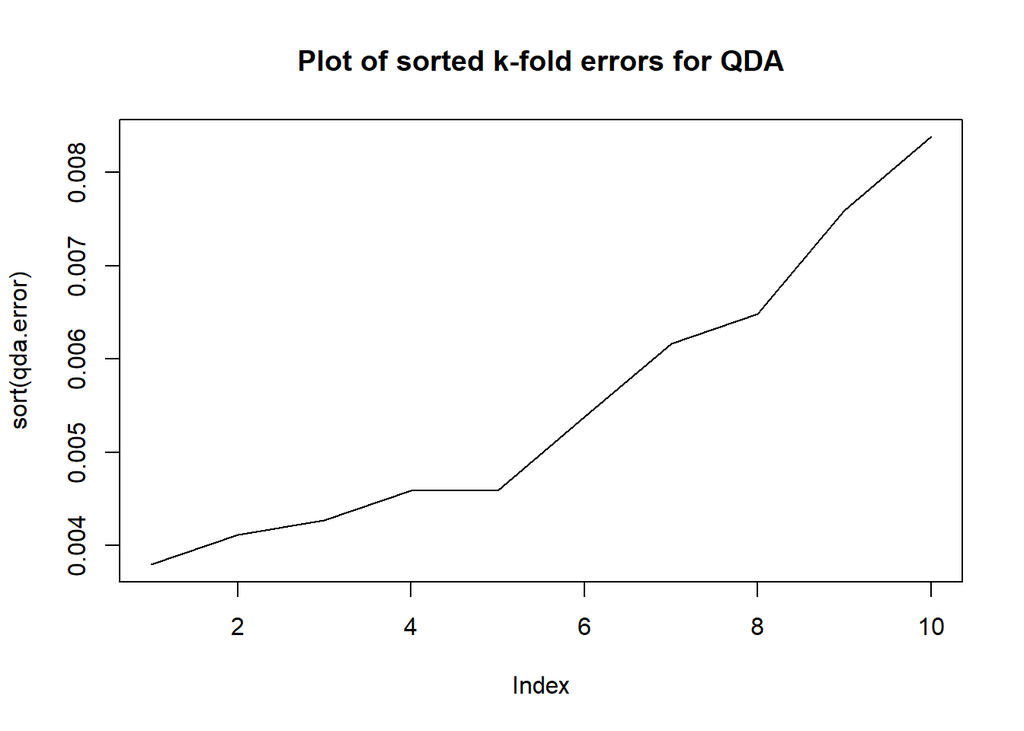

```r
#qda.table.adj


plot(sort(qda.error), type = "l", main="Plot of sorted k-fold errors for QDA")
```

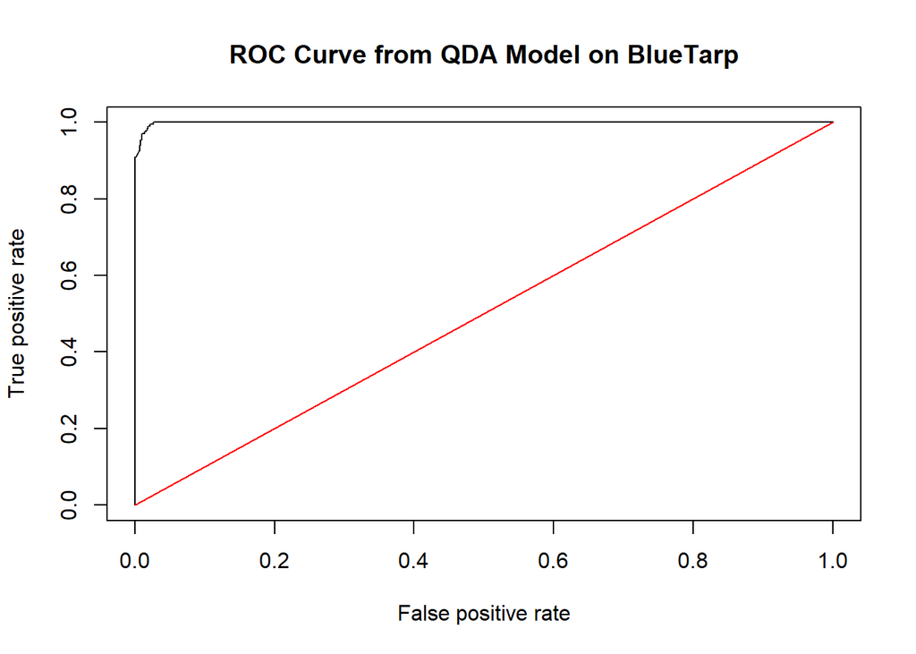

```r
#AUROC
library(ROCR)

#Apply to test data

qda.class = predict(qda.fit,haiti[haiti.test,] )$class #predictions of BlueTarp on test data
qda.pred = predict(qda.fit,haiti[haiti.test,] )

#Classification table for ROC
qda.btarp<-prediction(qda.pred$posterior[,2], as.data.frame(haiti$Class.Dummy[haiti.test]))

roc_data<-performance(qda.btarp, measure="tpr" , x.measure="fpr")
plot(roc_data, main="ROC Curve from QDA Model on BlueTarp")
lines( x = c(0,1), y = c(0,1),col="red")
```

```r
#Find AUC (higher is better)
auc<-performance(qda.btarp, measure = "auc")
qda.auc = auc@y.values[[1]]

##confusion matrix
qda.table = table(haiti$Class.Dummy[haiti.test],qda.class)


#from: https://rpubs.com/Kushan/295412
```

### 3.4.1 QDA Tuning

There aren’t specific tuning parameters in this model.

## 3.5 KNN

```r
library(class)
library(ROCR)
library(ISLR)
library(caret)
#k-fold 10
M = 10
n_test = as.integer(nrow(haiti)/M)

knn.error = numeric(M)
for(m in 1:M) {
  # Create test and train split
  haiti.test = sample(nrow(haiti), n_test)
  haiti.train = -haiti.test

# Fitting the model & Predictions
knn_mod = knn3(Class.Dummy~Red+Green+Blue, data=haiti[haiti.train,], k = 5) #knn model
knn.pred <- predict(knn_mod, haiti[haiti.test,], type = "prob") #predict onto holdout


knn.prob=knn.pred[,2]
#head(knn.prob)

knn.pred.class <- knn.prob > 0.05
knn.pred.class <- ifelse(knn.prob > 0.05,1,0)

# Test Error

test.Class.Dummy <- haiti[haiti.test,"Class.Dummy"]
knn.table = table(test.Class.Dummy,knn.pred.class)
knn.table

knn.error[m] = mean(test.Class.Dummy != knn.pred.class)


}

print("Test Error")
```

```
## [1] "Test Error"
```

```r
knn.error
```

```
##  [1] 0.008380772 0.008064516 0.008697027 0.008064516 0.006957622 0.011227071
##  [7] 0.009962049 0.007432005 0.009013283 0.009013283
```

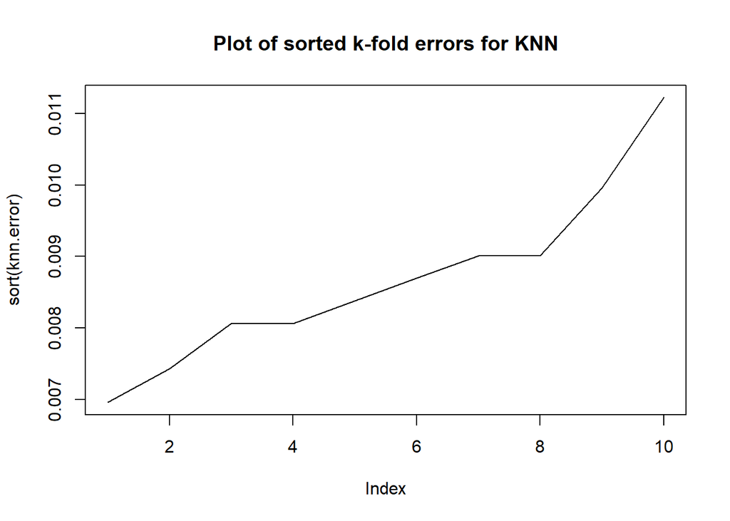

```r
plot(sort(knn.error), type = "l", main="Plot of sorted k-fold errors for KNN")
```

```r
knn.table
```

```
##                 knn.pred.class
## test.Class.Dummy    0    1
##                0 6077   56
##                1    1  190
```

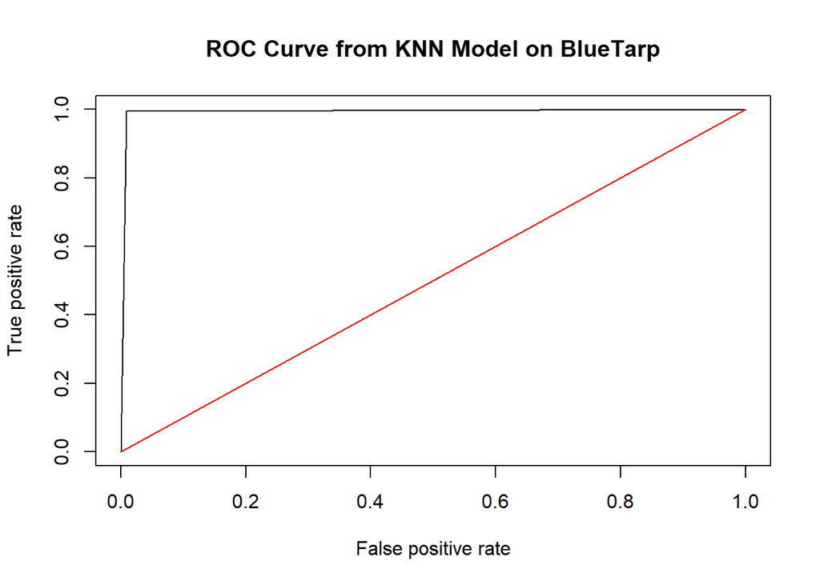

```r
#AUROC
#https://rstudio-pubs-static.s3.amazonaws.com/16444_caf85a306d564eb490eebdbaf0072df2.html

#Classification table for ROC
c_rate<-prediction(knn.pred.class, test.Class.Dummy )
roc_data<-performance(c_rate, measure="tpr" , x.measure="fpr")
plot(roc_data, main="ROC Curve from KNN Model on BlueTarp")
lines( x = c(0,1), y = c(0,1),col="red")
```

```r
#Find AUC
auc<-performance(c_rate, measure = "auc")
knn.auc <-auc@y.values[[1]]
```

### 3.5.1 Tuning Parameter $k$

I used a classification table to determine what tuning parameter to use for each k.. I compared k=1, k=3, k=5 and k=10 for a single training and test dataset (prior to k-fold 10). knn k=5 has best test error rate.

## 3.6 Penalized Logistic Regression (ElasticNet)

```r
library(glmnet)



#k folds (10)

set.seed(21)
plr.error = numeric(M)
for(m in 1:M) {
  # Create test and train split
  haiti.test = sample(nrow(haiti), n_test)
  haiti.train = -test
  train.x <- cbind(Red, Green, Blue )[haiti.train, ] #matrix containing predictors associated with training data
  test.x <- cbind(Red, Green, Blue)[haiti.test, ] #matrix containing predictors associated with testing data
  train.Class.Dummy = Class.Dummy[haiti.train] #vector containing class labels for the training observations
  BlueTarp = Class.Dummy[haiti.test]


  # Fitting the model & Predictions
  fit <- glmnet(train.x,train.Class.Dummy)
 cvfit <- cv.glmnet(haiti.matrix[ ,2:4],as.vector(Class.Dummy),nfolds=10)
  predict.BlueTarp <- predict(fit, newx=train.x,  s = cvfit$lambda.min)

  # Test Error

  summary(predict.BlueTarp, mean()) #to get cutoff
  plr.cutoff = mean(predict.BlueTarp)

  classify.BlueTarp <- ifelse(predict.BlueTarp > plr.cutoff, 1, 0)

  plr.table = table(train.Class.Dummy,classify.BlueTarp)

  plr.error[m] = mean(train.Class.Dummy != classify.BlueTarp)

}

print("Summary of Predicted Values of Blue Tarp")
```

```
## [1] "Summary of Predicted Values of Blue Tarp"
```

```r
  summary(predict.BlueTarp, mean()) #to get cutoff
```

```
##        1
##  Min.   :-0.37368
##  1st Qu.:-0.01961
##  Median : 0.01283
##  Mean   : 0.03219
##  3rd Qu.: 0.04743
##  Max.   : 0.73423
```

```r
plr.error
```

```
##  [1] 0.3037757 0.3037757 0.3037757 0.3037757 0.3037757 0.3037757 0.3037757
##  [8] 0.3037757 0.3037757 0.3037757
```

```r
plr.table
```

```
##                  classify.BlueTarp
## train.Class.Dummy     0     1
##                 0 37795 17290
##                 1     0  1832
```

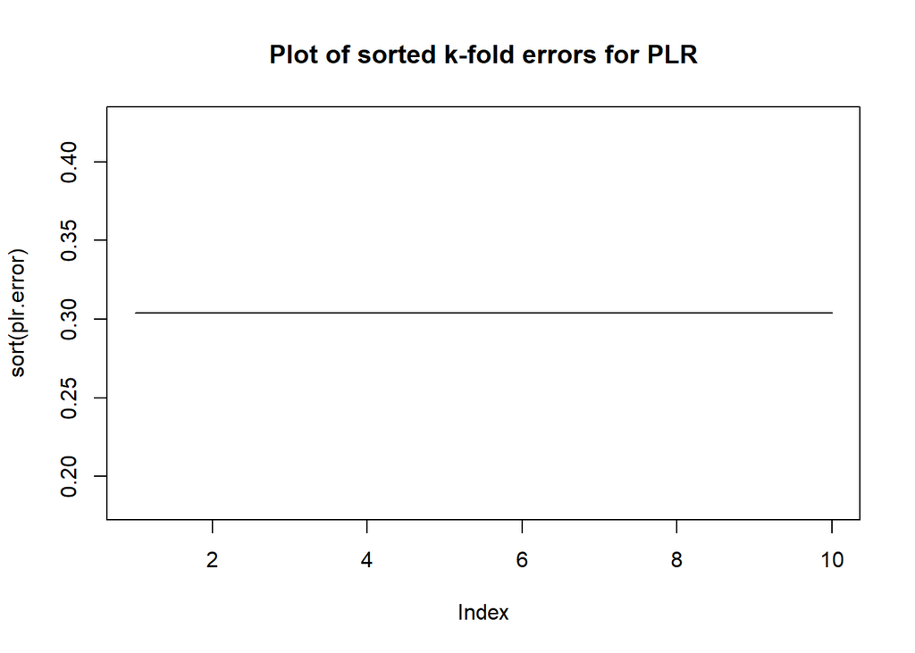

```r
plot(sort(plr.error), type = "l", main="Plot of sorted k-fold errors for PLR")
```

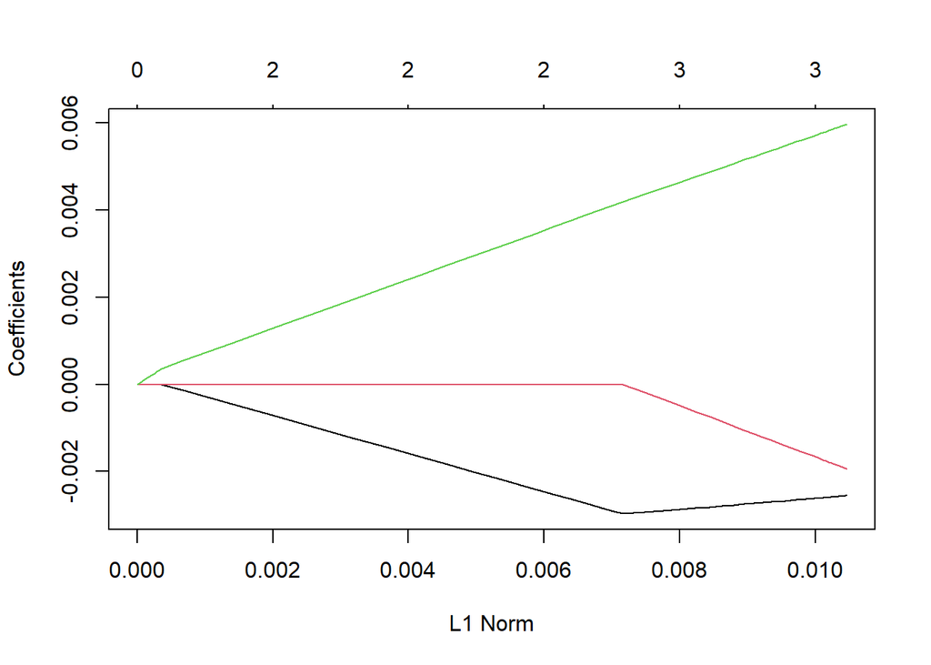

```r
plot(fit)
```

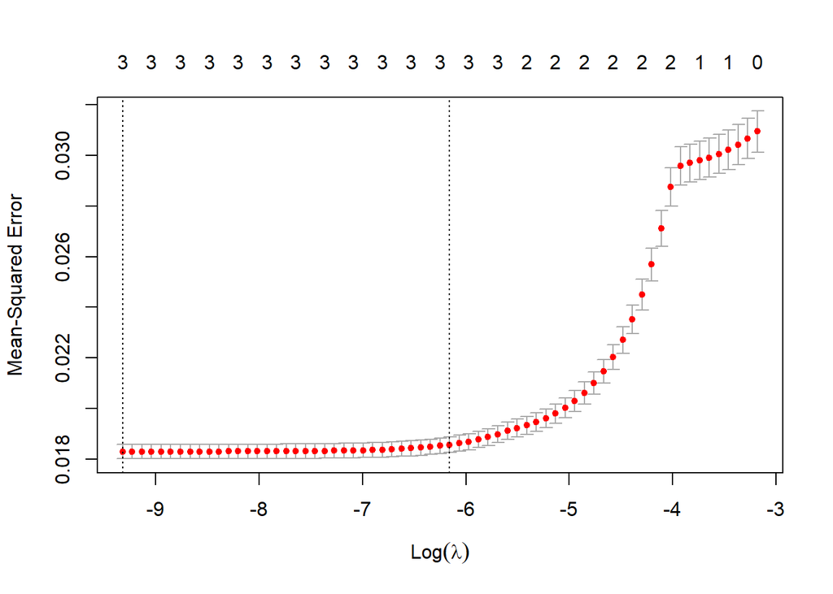

```r
plot(cvfit)
```

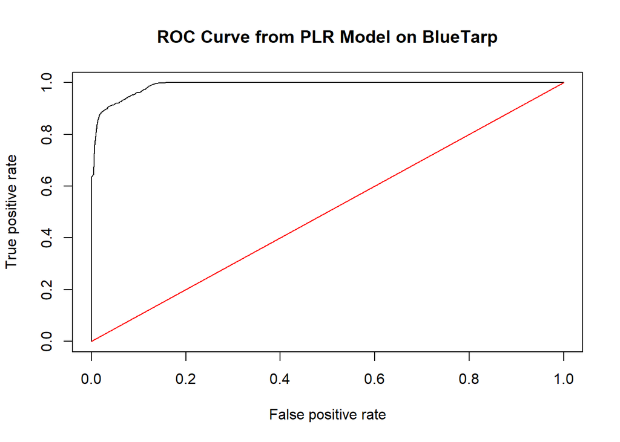

```r
#Classification table for ROC
c_rate<-prediction(predict.BlueTarp, train.Class.Dummy)
roc_data<-performance(c_rate, measure="tpr" , x.measure="fpr")
plot(roc_data, main="ROC Curve from PLR Model on BlueTarp")
lines( x = c(0,1), y = c(0,1),col="red")
```

```r
#Find AUC
plr.auc<-performance(c_rate, measure = "auc")
plr.auc <-auc@y.values[[1]]
```

### 3.6.1 Tuning Parameters

I looked at the fit (fit <- glmnet(haiti.matrix[ ,2:4],as.vector(Class.Dummy)). It shows from left to right the number of nonzero coefficients (Df), the percent (of null) deviance explained (%dev) and the value of λ (Lambda). So I chose a lambda that includes 3 df. The best alpha and lambda values are those values that minimize the cross-validation error.

### 3.6.2 Threshold Selection

#posterior probability cutoff tuning

In general, instead of arbitrarily choosing λ = 4, it would be better to use cross-validation to choose the tuning parameter λ. We can do this using # the built-in cross-validation function, cv.glmnet(). By default, the function cv.glmnet() performs ten-fold cross-validation, though this can be changed using the argument nfolds.

## 3.7 Random Forest

```r
#Bagging and Random Forests

library(randomForest)
```

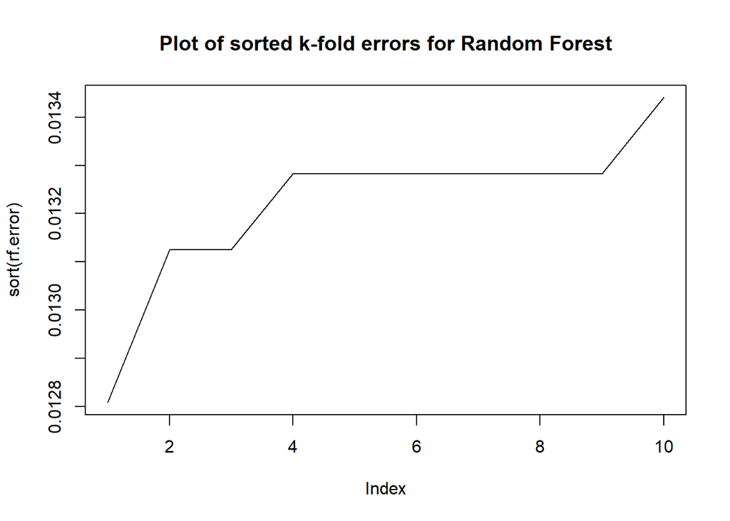

```r
set.seed(1)
rf.error = numeric(M)
M = 10
n_test = as.integer(nrow(haiti)/M)

for(m in 1:M) {
  # Create test and train split
  haiti.test = sample(nrow(haiti), n_test)
  haiti.train = -test

bag.haiti <- randomForest(haiti$Class.Dummy~Red+Red^2+Green+Green^2+Blue+Blue^2+Blue^3,data=haiti, subset=haiti.train,mtry=3,importance=TRUE, ntrees=500) #2 methods to decorrelate.
#1) bagging :pull random samples for the tree you are going to create
#2) split in each tree take subset of # of variables that are available
#mtry is the number of features we are going to try (variables)
#importance TRUE means keep importance values
bag.haiti
yhat.bag <-predict(bag.haiti, newdata=haiti[-haiti.train,])

yhat.class <- 0
yhat.class <- ifelse(yhat.bag > mean(yhat.bag),1,0)
rf.cutoff = mean(yhat.bag)

haiti.test=haiti[-haiti.train,"Class.Dummy"]

rf.table = table(haiti.test,yhat.class)
rf.error[m] = mean(haiti.test != yhat.class)
}


plot(sort(rf.error), type = "l", main="Plot of sorted k-fold errors for Random Forest")
```

```r
rf.table
```

```
##           yhat.class
## haiti.test    0    1
##          0 6050   84
##          1    0  190
```

```r
rf.error
```

```
##  [1] 0.01280835 0.01312460 0.01312460 0.01328273 0.01328273 0.01344086
##  [7] 0.01328273 0.01328273 0.01328273 0.01328273
```

```r
importance(bag.haiti)
```

```
##         %IncMSE IncNodePurity
## Red   47.942369     795.32616
## Green  8.948977      54.45638
## Blue  80.508837     890.34802
```

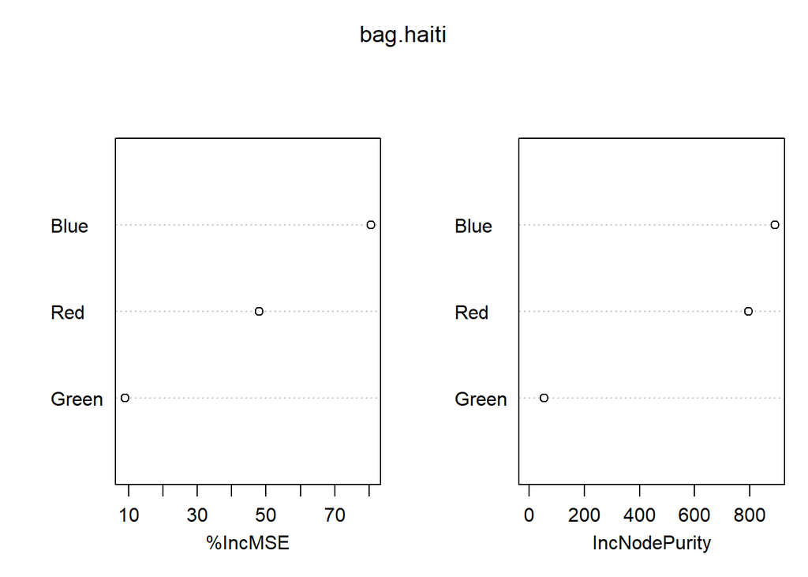

```r
varImpPlot(bag.haiti)
```

```r
haiti.Class.Dummy <- as.factor(haiti$Class.Dummy)


###############  Use best model for roc curve

library(randomForest)
library(pROC)
#https://stackoverflow.com/questions/46124424/how-can-i-draw-a-roc-curve-for-a-randomforest-model-with-three-classes-in-r

haiti.Class.Dummy <- as.factor(haiti$Class.Dummy)

bag.haiti <- randomForest(haiti.Class.Dummy~Red+Red^2+Green+Green^2+Blue+Blue^2+Blue^3,data=haiti, mtry=3,importance=TRUE, ntrees=500)

bag.haiti
```

```
##
## Call:
##  randomForest(formula = haiti.Class.Dummy ~ Red + Red^2 + Green +      Green^2 + Blue + Blue^2 + Blue^3, data = haiti, mtry = 3,      importance = TRUE, ntrees = 500)
##                Type of random forest: classification
##                      Number of trees: 500
## No. of variables tried at each split: 3
##
##         OOB estimate of  error rate: 0.31%
## Confusion matrix:
##       0    1 class.error
## 0 61139   80 0.001306784
## 1   115 1907 0.056874382
```

```r
yhat.bag <-predict(bag.haiti, newdata=haiti)
yhat.class <-as.data.frame(yhat.bag)

rf.table.ho <-table(haiti$Class.Dummy,yhat.bag) #(actual, predicted)
rf.table.ho
```

```
##    yhat.bag
##         0     1
##   0 61217     2
##   1    24  1998
```

```r
rf.error = mean(haiti$Class.Dummy != yhat.class$yhat.bag)
rf.error
```

```
## [1] 0.0004111257
```

```r
importance(bag.haiti)
```

```
##                0        1 MeanDecreaseAccuracy MeanDecreaseGini
## Red    46.869606 148.5860             51.49120         1759.953
## Green   7.990626  66.9282             65.84147          137.716
## Blue  101.206782 713.6488            110.59394         1977.025
```

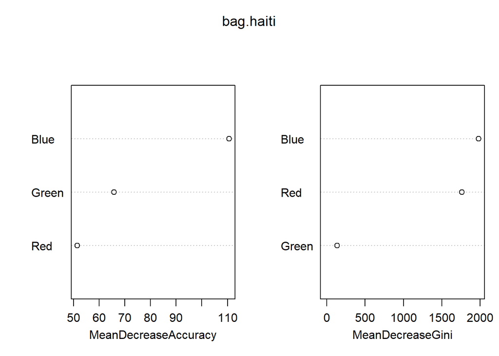

```r
varImpPlot(bag.haiti)
```

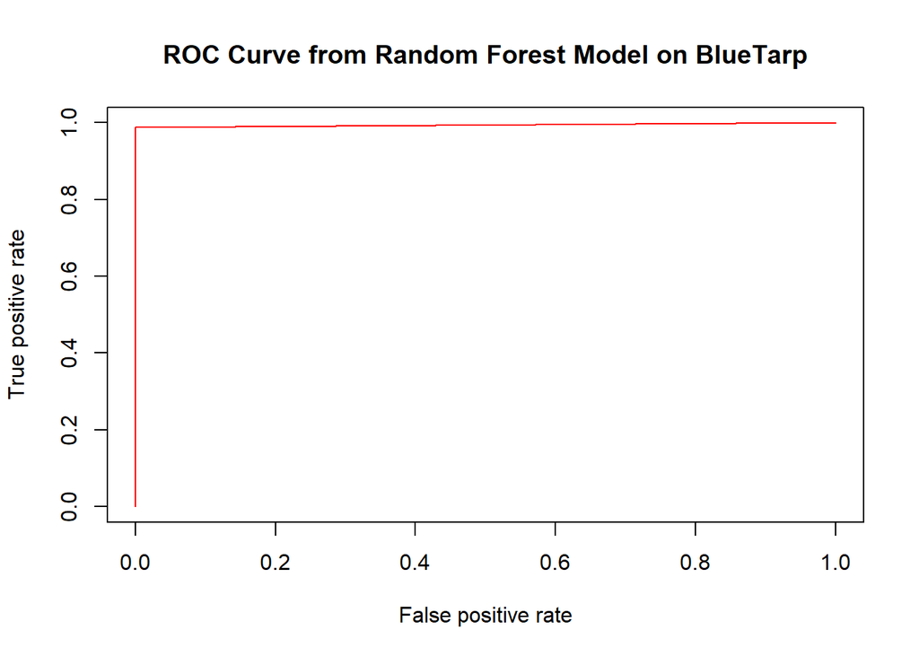

```r
#Classification table for ROC
predictions <- as.numeric(predict(bag.haiti, haiti, type="response"))
pred <- prediction(predictions, haiti$Class.Dummy)
perf <- performance(pred, measure = "tpr", x.measure = "fpr")
plot(perf, col=rainbow(10), main="ROC Curve from Random Forest Model on BlueTarp")
```

```r
rf.auc <- performance(pred,measure="auc")
rf.auc <-auc@y.values[[1]]
```

## 3.8 Tuning Parameters for Random Forest

I looked at different ntrees = 150, 500, and 1000. There was no difference in 500 & 1000 ntrees. At n=tree 150, the classification table added 1 observation as a False Negative, and I want to stay away from that. So I settled on ntree = 500 Without many features to choose from, mtry = 3 made the most sense.

#Support Vector Machines (allows us to use different kernels other than linear)

```r
# Gamma explains how far the influence of a single training example reaches. When gamma is very small, the model is too constrained and cannot capture the complexity or “shape” of the data.
library(e1071)
```

```r
set.seed(914)
test20 = .20*nrow(haiti)
haiti.test = sample(nrow(haiti),test20 )  #vector of obs numbers
haiti.train = -haiti.test                 #removal of obs numbers for matrix



svmfit=svm(Class.Dummy~Red+Green+Blue+Blue^2, data=haiti[haiti.train,],kernel="radial",gamma=2,cost=1, scale=TRUE)
plot(svmfit, haiti[haiti.train,])
summary(svmfit)
```

```
##
## Call:
## svm(formula = Class.Dummy ~ Red + Green + Blue + Blue^2, data = haiti[haiti.train,
##     ], kernel = "radial", gamma = 2, cost = 1, scale = TRUE)
##
##
## Parameters:
##    SVM-Type:  eps-regression
##  SVM-Kernel:  radial
##        cost:  1
##       gamma:  2
##     epsilon:  0.1
##
##
## Number of Support Vectors:  3793
```

```r
fitted=attributes(predict(svmfit,haiti,decision.values = TRUE)) $decision.values
pred <- predict(svmfit,haiti)

#table(true=holdout.all[,"Class.Dummy"],pred=predict(tune.out$best.model,newdata=haiti[haiti.test,]))
# svm.table.ho = table(true=holdout.all$Class.Dummy,pred=fitted)

svm.table <- table(haiti$Class.Dummy, pred)#(actual, predicted)
#svm.table


dat.te=data.frame(x=haiti[,2:4], y=as.factor(haiti$Class.Dummy ))
pred.te=predict (svmfit , newdata =dat.te)

#need to classify raw probabilities
svm.cutoff = .001
svm.class <- ifelse(pred.te > svm.cutoff, 1, 0)
svm.table <- table(dat.te$y,svm.class) #(actual, predicted)
svm.table
```

```
##    svm.class
##         0     1
##   0 43739 17480
##   1     0  2022
```

[figure not shown]

[output not shown]

[figure not shown]

```r
#ROC Curves
library (ROCR)
rocplot=function(pred.te,truth, ...) {
  predob = prediction(pred.te,truth)
  perf = performance(predob, "tpr" ,"fpr") #ignore the axes labels!! had to switch fpr and tpr to make plot correct
  plot(perf,...)}


par(mfrow=c(1,2)) #create one row two columns of figures to plot

rocplot(fitted, haiti[,"Class.Dummy"],main="ROC Curve from SVM Model on BlueTarp")
predob = prediction(pred.te,dat.te$y)
perf_val <- performance(predob,"auc")
svm.auc <-auc@y.values[[1]]
```

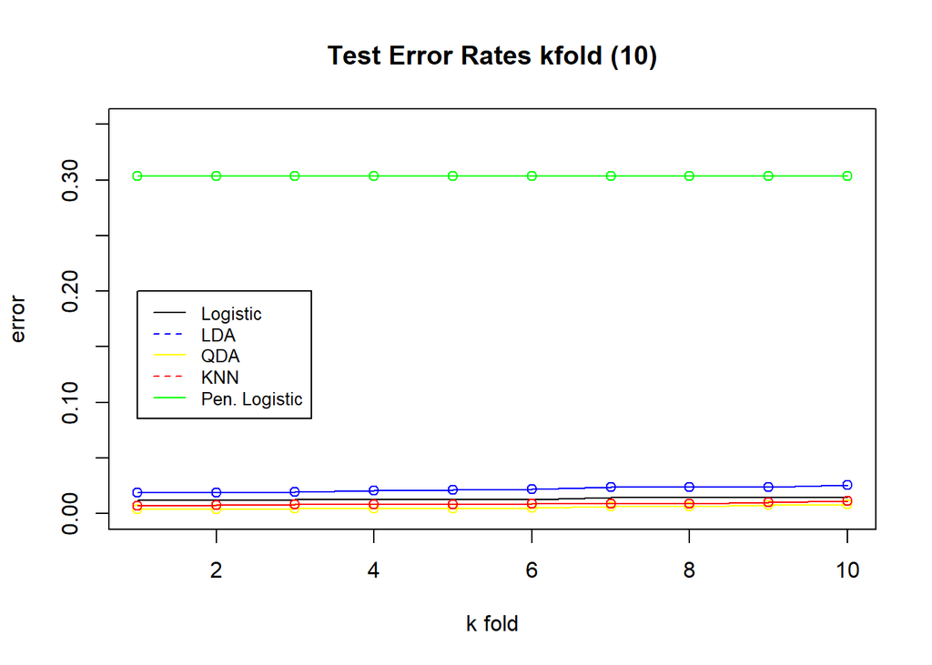

```r
plot(sort(logistic.error), type = "l", ylim=c(0,.35), main = "Test Error Rates kfold (10)", ylab="error", xlab="k fold")
points(sort(lda.error), col = "blue")
lines(sort(lda.error), col = "blue")

points(sort(qda.error),col = "yellow")
lines(sort(qda.error),col = "yellow")

points(sort(knn.error), col = "red")
lines(sort(knn.error), col = "red")

points(sort(plr.error), col = "green")
lines(sort(plr.error), col = "green")

legend(1,.20, legend=c("Logistic","LDA", "QDA", "KNN", "Pen. Logistic"),col=c("black","blue","yellow","red","green"), lty=1:2, cex=0.8)
```

##Performance Table

```r
pt <- setNames(data.frame(matrix(ncol = 8, nrow = 5)), c("Model", "Tuning", "AUROC" , "Threshold" , "Accuracy", "TPR", "FPR" , "Precision"))

pt[1,1] = "Logistic"
pt[2,1] = "LDA"
pt[3,1] = "QDA"
pt[4,1] = "KNN"
pt[5,1] = "PLR"
pt[6,1] = "R.Forest"
pt[7,1] = "SVM"

pt[1,2] = "   *   "  #tuning
pt[1,3] = formatC(lm.auc)           #AUC
pt[1,4] = formatC(lm.cutoff)        #threshold
pt[1,5] = formatC((lm.table[1,1]+lm.table[2,2]) / sum(lm.table)) #Accuracy
pt[1,6] = formatC((lm.table[2,2]) / sum(lm.table[2,]))           #TPR
pt[1,7] = formatC(lm.table[1,2] / sum(lm.table[1,]))             #FPR
pt[1,8] = formatC((lm.table[2,2])/ sum(lm.table[,2]))            #Precision


pt[2,2] = "   *   "  #tuning
pt[2,3] = formatC(lda.auc)           #AUC
pt[2,4] = formatC(lda.cutoff)        #threshold
pt[2,5] = formatC((lda.table[1,1]+lda.table[2,2]) / sum(lda.table)) #Accuracy
pt[2,6] = formatC((lda.table[2,2]) / sum(lda.table[2,]))           #TPR
pt[2,7] = formatC(lda.table[1,2] / sum(lda.table[1,]))             #FPR
pt[2,8] = formatC((lda.table[2,2])/ sum(lda.table[,2]))            #Precision



pt[3,2] = "   *   "  #tuning
pt[3,3] = formatC(qda.auc)           #AUC
pt[3,4] = formatC(qda.cutoff)        #threshold
pt[3,5] = formatC((qda.table[1,1]+qda.table[2,2]) / sum(qda.table)) #Accuracy
pt[3,6] = formatC((qda.table[2,2]) / sum(qda.table[2,]))           #TPR
pt[3,7] = formatC(qda.table[1,2] / sum(qda.table[1,]))             #FPR
pt[3,8] = formatC((qda.table[2,2])/ sum(qda.table[,2]))            #Precision




pt[4,2] = "k= 5    "  #tuning
pt[4,3] = formatC(knn.auc)           #AUC
pt[4,4] = formatC(.5)        #threshold
pt[4,5] = formatC((knn.table[1,1]+knn.table[2,2]) / sum(knn.table)) #Accuracy
pt[4,6] = formatC((knn.table[2,2]) / sum(knn.table[2,]))           #TPR
pt[4,7] = formatC(knn.table[1,2] / sum(knn.table[1,]))             #FPR
pt[4,8] = formatC((knn.table[2,2])/ sum(knn.table[,2]))            #Precision


pt[5,2] = formatC(cvfit$lambda.min)  #tuning
pt[5,3] = formatC(plr.auc)           #AUC
pt[5,4] = formatC(.5)        #threshold
pt[5,5] = formatC((plr.table[1,1]+plr.table[2,2]) / sum(plr.table)) #Accuracy
pt[5,6] = formatC((plr.table[2,2]) / sum(plr.table[2,]))           #TPR
pt[5,7] = formatC(plr.table[1,2] / sum(plr.table[1,]))             #FPR
pt[5,8] = formatC((plr.table[2,2])/ sum(plr.table[,2]))            #Precision



pt[6,2] = "mtry = 3 ntree=500"  #tuning
pt[6,3] = formatC(rf.auc)           #AUC
pt[6,4] = formatC(rf.cutoff)        #threshold
pt[6,5] = formatC((rf.table[1,1]+rf.table[2,2]) / sum(rf.table)) #Accuracy
pt[6,6] = formatC((rf.table[2,2]) / sum(rf.table[2,]))           #TPR
pt[6,7] = formatC(rf.table[1,2] / sum(rf.table[1,]))             #FPR
pt[6,8] = formatC((rf.table[2,2])/ sum(rf.table[,2]))            #Precision

pt[7,2] = "cost=1, gamma=2, kernel=radial"  #tuning
pt[7,3] = formatC(svm.auc)           #AUC
pt[7,4] = formatC(svm.cutoff)        #threshold
pt[7,5] = formatC((svm.table[1,1]+svm.table[2,2]) / sum(svm.table)) #Accuracy
pt[7,6] = formatC((svm.table[2,2]) / sum(svm.table[2,]))           #TPR
pt[7,7] = formatC(svm.table[1,2] / sum(svm.table[1,]))             #FPR
pt[7,8] = formatC((svm.table[2,2])/ sum(svm.table[,2]))            #Precision


#kable(pt[1:5,], width="20cm" , caption = "Performance Table")
pt
```

```
##      Model                         Tuning  AUROC Threshold Accuracy    TPR
## 1 Logistic                           *    0.9986     0.034   0.9817 0.9789
## 2      LDA                           *    0.9904     0.015   0.9807  0.881
## 3      QDA                           *     0.999       0.5   0.9962 0.8856
## 4      KNN                       k= 5     0.9928       0.5    0.991 0.9948
## 5      PLR                      8.965e-05 0.9928       0.5   0.6962      1
## 6 R.Forest             mtry = 3 ntree=500 0.9928   0.03071   0.9867      1
## 7      SVM cost=1, gamma=2, kernel=radial 0.9928     0.001   0.7236      1
##         FPR Precision
## 1   0.01826    0.6242
## 2   0.01587     0.656
## 3 0.0001633    0.9944
## 4  0.009131    0.7724
## 5    0.3139   0.09581
## 6   0.01369    0.6934
## 7    0.2855    0.1037
```

## 3.9 ROC CURVES

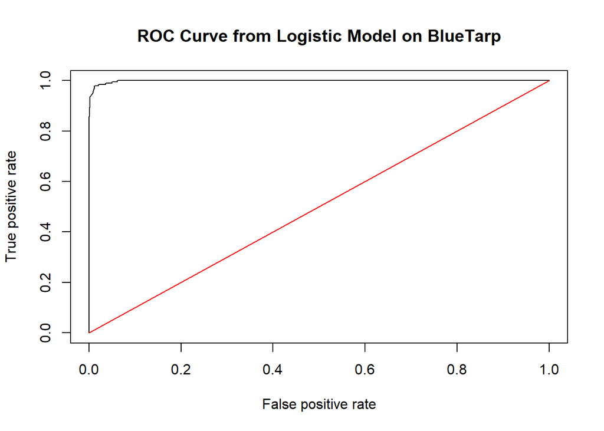

```r
library(ROCR)

#Logistic ROC
c_rate<-prediction(p_hat, haiti$Class.Dummy[test])
roc_data<-performance(c_rate, measure="tpr" , x.measure="fpr")
plot(roc_data, main="ROC Curve from Logistic Model on BlueTarp")
lines( x = c(0,1), y = c(0,1),col="red")
```

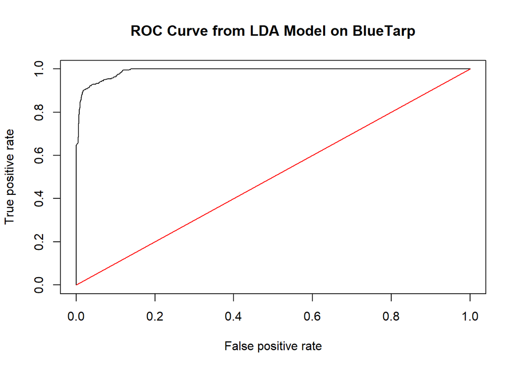

```r
#LDA ROC
#Apply to test data

lda.pred = predict(lda.fit, haiti[haiti.test,])

#Convert posteriors to dataframe
lda.pred.post <-as.data.frame(lda.pred$posterior)

#Classification table for ROC
lda.btarp<-prediction(lda.pred.post[,2], as.data.frame(haiti$Class.Dummy[haiti.test]))
roc_data<-performance(lda.btarp, measure="tpr" , x.measure="fpr")
plot(roc_data, main="ROC Curve from LDA Model on BlueTarp")
lines( x = c(0,1), y = c(0,1),col="red")
```

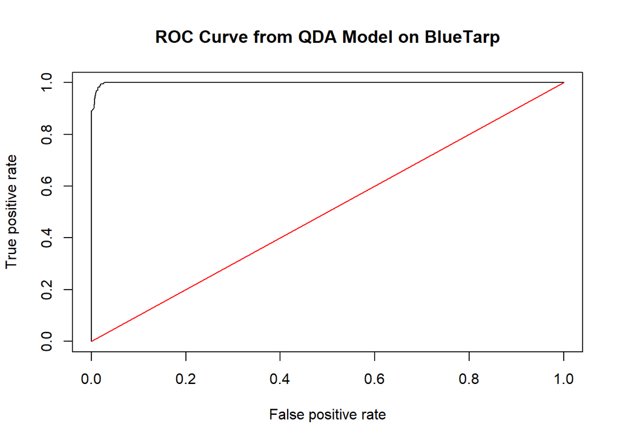

```r
#QDA ROC
#Apply to test data

qda.class = predict(qda.fit,haiti[haiti.test,] )$class #predictions of BlueTarp on test data
qda.pred = predict(qda.fit,haiti[haiti.test,] )

#Classification table for ROC
qda.btarp<-prediction(qda.pred$posterior[,2], as.data.frame(haiti$Class.Dummy[haiti.test]))

roc_data<-performance(qda.btarp, measure="tpr" , x.measure="fpr")
plot(roc_data, main="ROC Curve from QDA Model on BlueTarp")
lines( x = c(0,1), y = c(0,1),col="red")
```

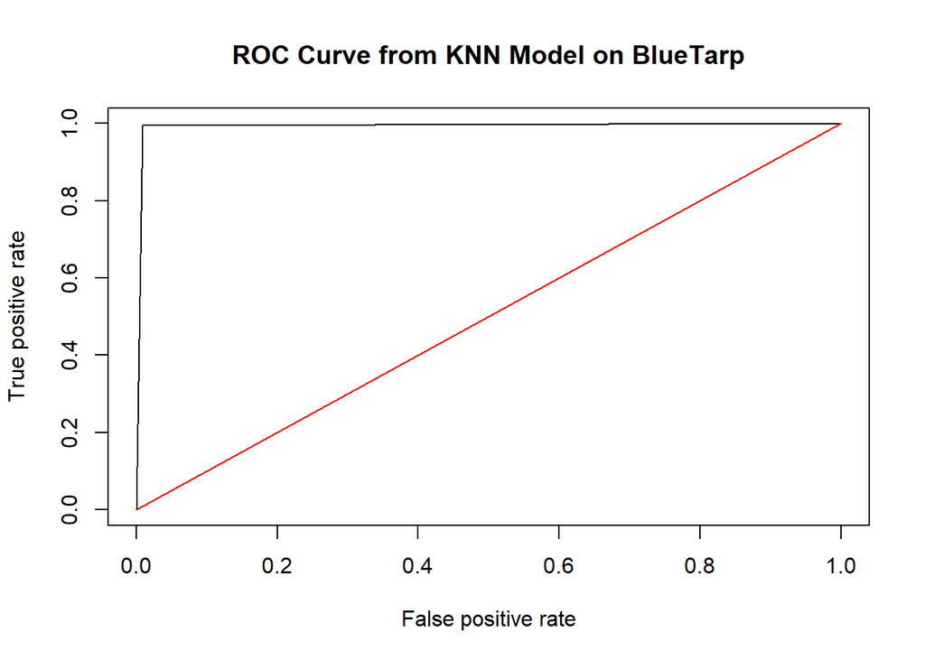

```r
#KNN Classification table for ROC
#Classification table for ROC
c_rate<-prediction(knn.pred.class, test.Class.Dummy )
roc_data<-performance(c_rate, measure="tpr" , x.measure="fpr")
plot(roc_data, main="ROC Curve from KNN Model on BlueTarp")
lines( x = c(0,1), y = c(0,1),col="red")
```

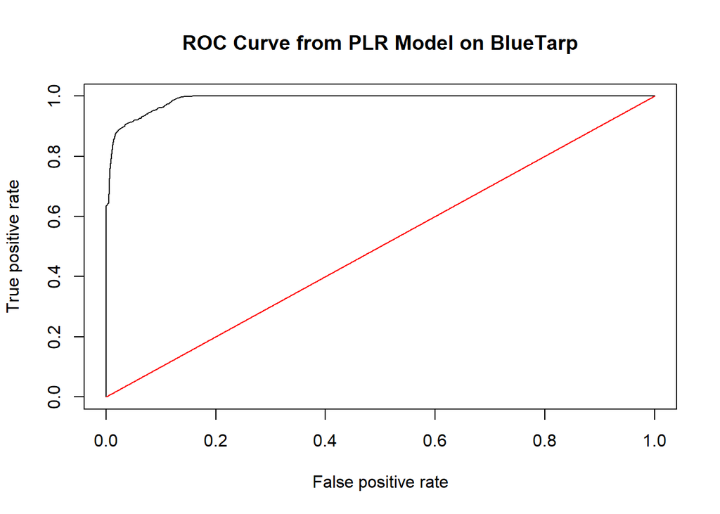

```r
#PLR ROC
c_rate<-prediction(predict.BlueTarp, train.Class.Dummy)
roc_data<-performance(c_rate, measure="tpr" , x.measure="fpr")
plot(roc_data, main="ROC Curve from PLR Model on BlueTarp")
lines( x = c(0,1), y = c(0,1),col="red")
```

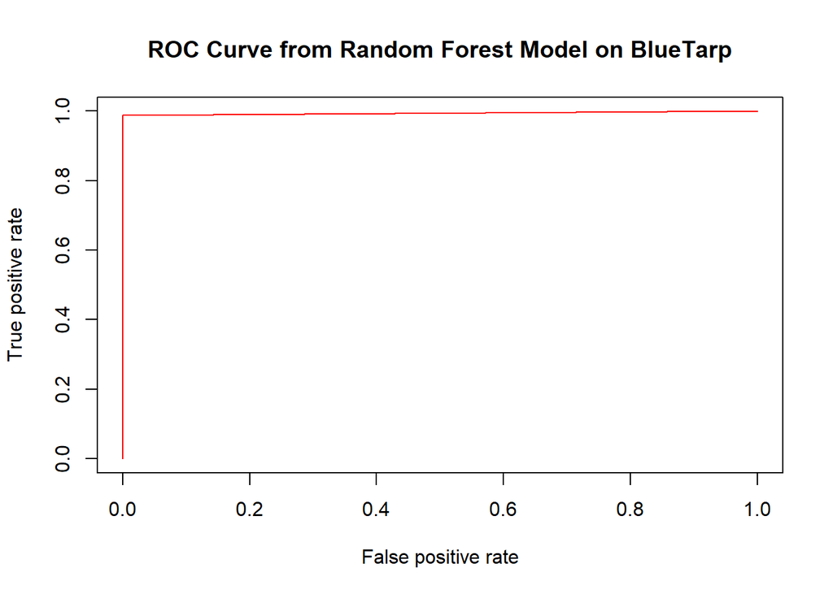

```r
#Classification table for ROC Random F.
predictions <- as.numeric(predict(bag.haiti, haiti, type="response"))
pred <- prediction(predictions, haiti$Class.Dummy)
perf <- performance(pred, measure = "tpr", x.measure = "fpr")
plot(perf, col=rainbow(10), main="ROC Curve from Random Forest Model on BlueTarp")
```

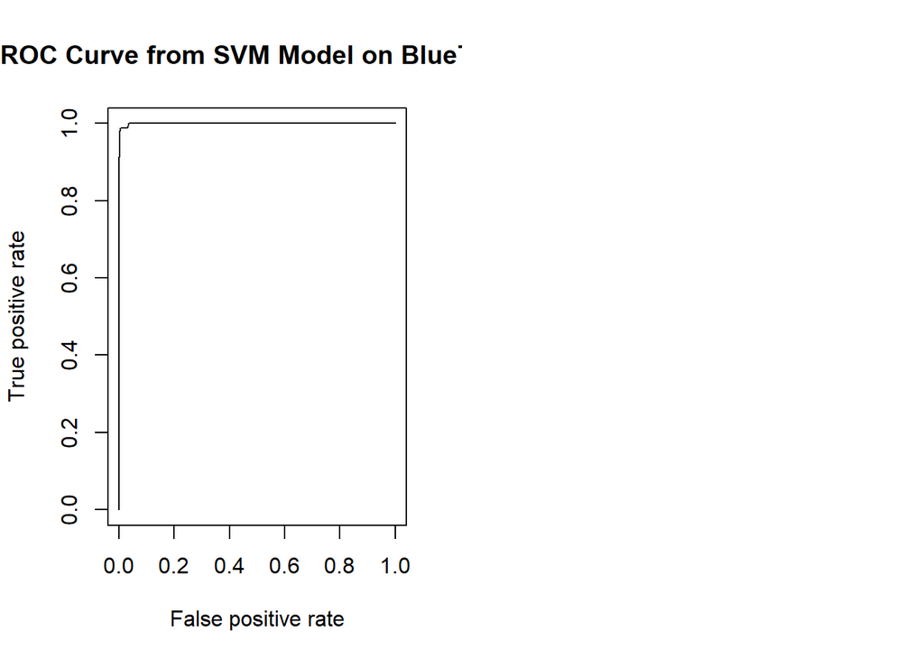

```r
#ROC Curves for SVM
library (ROCR)
rocplot=function(pred.te,truth, ...) {
  predob = prediction(pred.te,truth)
  perf = performance(predob, "tpr" ,"fpr") #ignore the axes labels!! had to switch fpr and tpr to make plot correct
  plot(perf,...)}


par(mfrow=c(1,2)) #create one row two columns of figures to plot

rocplot(fitted, haiti[,"Class.Dummy"],main="ROC Curve from SVM Model on BlueTarp")
```